# Taller R 08: interaccion

dacarras

# Introducción

- Esta tarea contiene diferentes ejercicios para analizar datos empleando modelos de regresión. En esta tarea, vamos a ajustar una serie de modelos de regresión para evaluar la relación que poseen un conjunto de factores respecto al salario de profesores universitarios de 1981 (Rabe-Hesketh & Srondal, 2012, p247).
- Los datos originales han sido expandidos de forma tal, que los resultados generados por los análisis de regresión a emplear, y con diferentes muestras aleatorias, se asemejen a los resultados producidos por los datos originales. En esta tarea solo incluímos un conjunto menor de variables del ejemplo orignal.
- La base de datos que emplearemos contiene a la siguientes variables:

```
# Muestra de valores
id_i     <int> 1, 2, 3, 4, 5, 6, 7, 8, 9
lwage    <dbl> 1.17522335, 2.20148897, 1
ethn     <int> 0, 0, 0, 2, 1, 0, 0, 0, 2
union    <int> 1, 0, 0, 0, 0, 0, 0, 0, 1
educ     <int> 15, 15, 12, 11, 12, 14, 1


# Contenido de las variables
id_i     = numero único identificador de las observaciones
lwage    = salario en logaritmo
ethn     = etnicidad (0 = blanco, 1 = africano-americano, 2 = hispánico/latino)
union    = membresía al sindicato (0 = no, 1 = sí)
educ     = años de educacion (min = 3, max = 16)
```

- El archivo que contiene los datos, es el siguiente:

```
salary_1981.csv
```

# Referencias

Rabe-Hesketh, S., & Skrondal, A. (2012). Multilevel and Longitudinal Modeling Using Stata, Volumes I and II, Third Edition (3rd ed.). Stata Press.

# Ejercicio 1. Abrir datos.

- Inserte los códigos para abrir la base de datos `salary_1981.csv`. Llame al objeto con sus datos `datos_full`. Considere utilizar la funcion `read.csv()`.

```r
# abrir datos
datos_full <- read.csv('salary_1981.csv')
```

# Ejercicio 2. Preparar datos.

- Ejecute los siguientes comandos reemplazando el valor ‘123456789’ por su Rut para crear y guardar una submuestra de 1000 en total. No altere el resto de los comandos. Guardelo en un objeto denominado `datos_salarios`.

```r
# Fijar el seed, permite obtener la misma muestra aleatoria,
#                cada vez que trabaje con el codigo.
#                Es importante que los datos de su tarea,
#                sean generados con su RUT.

library(dplyr)
set.seed(1234567890)
datos_salarios <- datos_full %>%
                  dplyr::slice_sample(n = 1000)
```

> Los siguientes ejercicios se realizan utilizando el objeto denominado “datos_salarios”.

# Ejercicio 3. Descriptivos

- Antes de ajustar modelos de regresión, es una buena práctica tener información sobre las variables que serán analizadas.
- Calcule las siguientes descriptivos para cada una de las variables incluidas:
  - Valor mínimo de cada variable
  - Valor maximo de cada variable
  - Proporción de casos en cada valor para las variables categóricas (union, ethn)
  - Mediana de las variables cuantitativas (lwage, educ)
  - Media de las variables cuantitativas (lwage, educ)
  - Desviación estándar de las variables cuantitativas (lwage, educ)

> Nota: el detalle de los descriptivos solicitados por variable también se especifica en la sección de respuestas.

```r
# descriptivos

# lwage
datos_salarios %>%
summarize(
min  = min(lwage, na.rm = TRUE),
max  = max(lwage, na.rm = TRUE),
med  = median(lwage, na.rm = TRUE),
mean = mean(lwage, na.rm = TRUE),
des  = sd(lwage, na.rm = TRUE)
) %>%
knitr::kable(., digits = 2)
```

| min | max | med | mean | des |
| --- | --- | --- | --- | --- |
| -1.42 | 2.94 | 1.57 | 1.51 | 0.51 |

```r
# educ
datos_salarios %>%
summarize(
min  = min(educ, na.rm = TRUE),
max  = max(educ, na.rm = TRUE),
med  = median(educ, na.rm = TRUE),
mean = mean(educ, na.rm = TRUE),
des  = sd(educ, na.rm = TRUE)
) %>%
knitr::kable(., digits = 2)
```

| min | max | med | mean | des |
| --- | --- | --- | --- | --- |
| 3 | 16 | 12 | 11.75 | 1.76 |

```r
## freq
dplyr::count(datos_salarios, educ)
```

```
##    educ   n
## 1     3   3
## 2     5   4
## 3     6   5
## 4     7   5
## 5     8  40
## 6     9  33
## 7    10  79
## 8    11 174
## 9    12 410
## 10   13 107
## 11   14  82
## 12   15  52
## 13   16   6
```

```r
# ethn
datos_salarios %>%
summarize(
min  = min(ethn, na.rm = TRUE),
max  = max(ethn, na.rm = TRUE),
prop_0 = mean(ethn == 0, na.rm = TRUE),
prop_1 = mean(ethn == 1, na.rm = TRUE),
prop_2 = mean(ethn == 2, na.rm = TRUE)
) %>%
knitr::kable(., digits = 2)
```

| min | max | prop_0 | prop_1 | prop_2 |
| --- | --- | --- | --- | --- |
| 0 | 2 | 0.73 | 0.12 | 0.15 |

```r
## freq
dplyr::count(datos_salarios, ethn)
```

```
##   ethn   n
## 1    0 726
## 2    1 125
## 3    2 149
```

```r
# union
datos_salarios %>%
summarize(
min  = min(union, na.rm = TRUE),
max  = max(union, na.rm = TRUE),
prop_0 = mean(union == 0, na.rm = TRUE),
prop_1 = mean(union == 1, na.rm = TRUE)
) %>%
knitr::kable(., digits = 2)
```

| min | max | prop_0 | prop_1 |
| --- | --- | --- | --- |
| 0 | 1 | 0.74 | 0.26 |

```r
## freq
dplyr::count(datos_salarios, union)
```

```
##   union   n
## 1     0 744
## 2     1 256
```

- **Respuesta**
  - lwage
    - mínimo: -1.42
    - máximo: 2.94
    - mediana: 1.57
    - media: 1.51
    - desviación estándar: 0.51
  - educ
    - mínimo: 3
    - máximo: 16
    - mediana: 12
    - media: 11.75
    - desviación estándar: 1.76
  - ethn
    - mínimo: 0
    - máximo: 2
    - proporción de cada categoria: 0 = .73; 1 = .12; 2 = .15
  - union
    - mínimo: 0
    - máximo: 1
    - proporción de cada categoria: 0 = .74; 1 = .26

# Ejercicio 4

- Ajuste un ANOVA factorial con el logaritmo del salario por hora (“lwage”) como variable de respuesta y dos predictores: la etnia del trabajador (“ethn”) y si pertenece a un sindicato (“union”).
- Incluya la interacción de ambos predictores en el modelo.
- Interprete los resultados. En su respuesta, indique si hay interacción entre ambos factores incluidos.

```r
# Escriba y edite el codigo que permita resolver el ejercicio.

aov(lwage ~ as.factor(ethn) + union + as.factor(ethn):union, data = datos_salarios) %>%
anova()
```

```
## Analysis of Variance Table
##
## Response: lwage
##                        Df  Sum Sq Mean Sq F value   Pr(>F)
## as.factor(ethn)         2   2.424  1.2119  4.9262 0.007432 **
## union                   1  11.854 11.8537 48.1854 6.99e-12 ***
## as.factor(ethn):union   2   3.071  1.5357  6.2427 0.002022 **
## Residuals             994 244.527  0.2460
## ---
## Signif. codes:  0 '***' 0.001 '**' 0.01 '*' 0.05 '.' 0.1 ' ' 1
```

```r
# Nota: es importante incluir a ethn como factor, o como conjunto de dummies.
#       De lo contrario aov() asume a ethn como variable continua, en vez
#       de considerar que son 3 categorias diferentes. Y como consecuencia,
#       subestima los grados de libertad del factor.


datos_salarios %>%
mutate(et0 = dplyr::if_else(ethn == 0, 1, 0)) %>%
mutate(et1 = dplyr::if_else(ethn == 1, 1, 0)) %>%
mutate(et2 = dplyr::if_else(ethn == 2, 1, 0)) %>%
aov(lwage ~ et1 + et2 + union + union:et1 + union:et2, data = .) %>%
anova()
```

```
## Analysis of Variance Table
##
## Response: lwage
##            Df  Sum Sq Mean Sq F value   Pr(>F)
## et1         1   0.004  0.0041  0.0167 0.897138
## et2         1   2.420  2.4196  9.8357 0.001762 **
## union       1  11.854 11.8537 48.1854 6.99e-12 ***
## et1:union   1   0.596  0.5962  2.4235 0.119848
## et2:union   1   2.475  2.4753 10.0619 0.001560 **
## Residuals 994 244.527  0.2460
## ---
## Signif. codes:  0 '***' 0.001 '**' 0.01 '*' 0.05 '.' 0.1 ' ' 1
```

```r
# Nota: Notese que el modelo empleando a los dummies es equivalente
#       al modelo incluyendo a la variable ethn como factor.
#       En ambos casos la suma de cuadrados es igual (al inlcuir todas las categorias).
```

## Respuesta

En el analisis de varianza (ANOVA) ajustado, incluyendo a los factores de etnia (ethn) de tres categorias, y de membresía sindical (union) de dos categorías se obtienen resultados significativos para los efectos principales respecto a cada factor. Es decir, que se esperan diferencias entre las categorias de cada factor sobre la variable de respuesta de logaritmo de salarios (lwage).

Por su parte, el termino de interacción de ambos factores, etnia y membresia al sindicato tambien es significativo. Lo anterior implica que las diferencias de medias de los grupos generados por ambos factores (etnia y membresía sindical) son diferentes por sobre el azar.

# Ejercicio 5

- Ajuste una regresión múltiple evaluando el efecto sobre el logaritmo del salario por hora (“lwage”) de los predictores la etnia del trabajador (“ethn”) y si pertenece a un sindicato (“union”).
- Incluya la interacción de ambos predictores en el modelo.
- Interprete cada uno de los coeficientes en los resultados.

```r
lm(lwage ~ as.factor(ethn) + union + as.factor(ethn):union, data = datos_salarios) %>%
summary()
```

```
##
## Call:
## lm(formula = lwage ~ as.factor(ethn) + union + as.factor(ethn):union,
##     data = datos_salarios)
##
## Residuals:
##      Min       1Q   Median       3Q      Max
## -2.88941 -0.22320  0.03191  0.31128  1.46512
##
## Coefficients:
##                        Estimate Std. Error t value Pr(>|t|)
## (Intercept)             1.47234    0.02103  69.997  < 2e-16 ***
## as.factor(ethn)1       -0.10377    0.05964  -1.740  0.08215 .
## as.factor(ethn)2       -0.06329    0.05196  -1.218  0.22344
## union                   0.28581    0.04347   6.575 7.85e-11 ***
## as.factor(ethn)1:union  0.09664    0.10174   0.950  0.34240
## as.factor(ethn)2:union -0.32187    0.10147  -3.172  0.00156 **
## ---
## Signif. codes:  0 '***' 0.001 '**' 0.01 '*' 0.05 '.' 0.1 ' ' 1
##
## Residual standard error: 0.496 on 994 degrees of freedom
## Multiple R-squared:  0.06625,    Adjusted R-squared:  0.06155
## F-statistic:  14.1 on 5 and 994 DF,  p-value: 2.385e-13
```

```r
# Nota: es importante incluir a ethn como factor, o como conjunto de dummies.
#       De lo contrario lm() asume a ethn como variable continua, en vez
#       de considerar que son 3 categorias diferentes. Y como consecuencia,
#       subestima los grados de libertad del factor.


datos_salarios %>%
mutate(et0 = dplyr::if_else(ethn == 0, 1, 0)) %>%
mutate(et1 = dplyr::if_else(ethn == 1, 1, 0)) %>%
mutate(et2 = dplyr::if_else(ethn == 2, 1, 0)) %>%
lm(lwage ~ et1 + et2 + union + union:et1 + union:et2, data = .) %>%
summary()
```

```
##
## Call:
## lm(formula = lwage ~ et1 + et2 + union + union:et1 + union:et2,
##     data = .)
##
## Residuals:
##      Min       1Q   Median       3Q      Max
## -2.88941 -0.22320  0.03191  0.31128  1.46512
##
## Coefficients:
##             Estimate Std. Error t value Pr(>|t|)
## (Intercept)  1.47234    0.02103  69.997  < 2e-16 ***
## et1         -0.10377    0.05964  -1.740  0.08215 .
## et2         -0.06329    0.05196  -1.218  0.22344
## union        0.28581    0.04347   6.575 7.85e-11 ***
## et1:union    0.09664    0.10174   0.950  0.34240
## et2:union   -0.32187    0.10147  -3.172  0.00156 **
## ---
## Signif. codes:  0 '***' 0.001 '**' 0.01 '*' 0.05 '.' 0.1 ' ' 1
##
## Residual standard error: 0.496 on 994 degrees of freedom
## Multiple R-squared:  0.06625,    Adjusted R-squared:  0.06155
## F-statistic:  14.1 on 5 and 994 DF,  p-value: 2.385e-13
```

```r
# Nota: Notese que el modelo empleando a los dummies es equivalente
#       al modelo incluyendo a la variable ethn como factor.
#       En ambos casos la suma de cuadrados es igual (al inlcuir todas las categorias).

datos_salarios %>%
mutate(et0 = dplyr::if_else(ethn == 0, 1, 0)) %>%
mutate(et1 = dplyr::if_else(ethn == 1, 1, 0)) %>%
mutate(et2 = dplyr::if_else(ethn == 2, 1, 0)) %>%
lm(lwage ~ et1 + et2 + union + union:et1 + union:et2, data = .) %>%
summary()
```

```
##
## Call:
## lm(formula = lwage ~ et1 + et2 + union + union:et1 + union:et2,
##     data = .)
##
## Residuals:
##      Min       1Q   Median       3Q      Max
## -2.88941 -0.22320  0.03191  0.31128  1.46512
##
## Coefficients:
##             Estimate Std. Error t value Pr(>|t|)
## (Intercept)  1.47234    0.02103  69.997  < 2e-16 ***
## et1         -0.10377    0.05964  -1.740  0.08215 .
## et2         -0.06329    0.05196  -1.218  0.22344
## union        0.28581    0.04347   6.575 7.85e-11 ***
## et1:union    0.09664    0.10174   0.950  0.34240
## et2:union   -0.32187    0.10147  -3.172  0.00156 **
## ---
## Signif. codes:  0 '***' 0.001 '**' 0.01 '*' 0.05 '.' 0.1 ' ' 1
##
## Residual standard error: 0.496 on 994 degrees of freedom
## Multiple R-squared:  0.06625,    Adjusted R-squared:  0.06155
## F-statistic:  14.1 on 5 and 994 DF,  p-value: 2.385e-13
```

```r
datos_salarios %>%
mutate(et0 = dplyr::if_else(ethn == 0, 1, 0)) %>%
mutate(et1 = dplyr::if_else(ethn == 1, 1, 0)) %>%
mutate(et2 = dplyr::if_else(ethn == 2, 1, 0)) %>%
lm(lwage ~ et1 + et2 + union + union:et1 + union:et2, data = .) %>%
report::report()
```

```
## We fitted a linear model (estimated using OLS) to predict lwage with et1, et2
## and union (formula: lwage ~ et1 + et2 + union + union:et1 + union:et2). The
## model explains a statistically significant and weak proportion of variance (R2
## = 0.07, F(5, 994) = 14.10, p < .001, adj. R2 = 0.06). The model's intercept,
## corresponding to et1 = 0, et2 = 0 and union = 0, is at 1.47 (95% CI [1.43,
## 1.51], t(994) = 70.00, p < .001). Within this model:
##
##   - The effect of et1 is statistically non-significant and negative (beta =
## -0.10, 95% CI [-0.22, 0.01], t(994) = -1.74, p = 0.082; Std. beta = -0.05, 95%
## CI [-0.11, 0.01])
##   - The effect of et2 is statistically non-significant and negative (beta =
## -0.06, 95% CI [-0.17, 0.04], t(994) = -1.22, p = 0.223; Std. beta = -0.10, 95%
## CI [-0.16, -0.04])
##   - The effect of union is statistically significant and positive (beta = 0.29,
## 95% CI [0.20, 0.37], t(994) = 6.57, p < .001; Std. beta = 0.21, 95% CI [0.15,
## 0.27])
##   - The effect of et1 × union is statistically non-significant and positive (beta
## = 0.10, 95% CI [-0.10, 0.30], t(994) = 0.95, p = 0.342; Std. beta = 0.03, 95%
## CI [-0.03, 0.08])
##   - The effect of et2 × union is statistically significant and negative (beta =
## -0.32, 95% CI [-0.52, -0.12], t(994) = -3.17, p = 0.002; Std. beta = -0.10, 95%
## CI [-0.16, -0.04])
##
## Standardized parameters were obtained by fitting the model on a standardized
## version of the dataset. 95% Confidence Intervals (CIs) and p-values were
## computed using a Wald t-distribution approximation.
```

## Respuesta

Ajustamos un modelo de regresión sobre el logaritmo de salarios (lwage), incluyendo a los factores de etnia (ethn), membresía sindical (unio) junto a términos de interacción entre ambos factores. Este modelo ajusta mejor a los datos que un modelo nulo (F(5, 994) = 14.10), p < .001), y explica una porción pequeña de la varianza de la varaible de respuesta (R2 = .07).

Por su parte, el efecto principal de la membresia sindical resulta significativa. Los resultados del mdoelo indican que los profesores con afiliación sindical, presentan salarios mayores al resto de los profesores (b = 0.29, SE = 0.04, t(994) = 6.57, p < .001).

Finalmente, los terminos de interacción indican que la relación entre etnia y afiliación sindical no beneficia a todos los profresores de la misma forma. Mientras la afiliacion sindical no presenta moderación de resultados para los profesores afroamericanos (b = 0.10, t(994) = 0.95, p = 0.342); si la presenta para los profesores hispano-latinos. Las medias de salarios de los profesores hispano-latinos, con afiliación sindical se espera que presenten salarios menores al resto de sus pares (beta = -0.32, t(994) = -3.17, p < 0.01).

> Nota: se incluye en parentesis SE para los errores estandares de los estimados, por el ingles `standard error`.

# Ejercicio 6

- Ajuste un ANCOVA con al logaritmo del salario por hora (“lwage”) como variable de respuesta que solo considere los efectos principales de etnia del trabajador (“ethn”), si pertenece a un sindicato (“union”) e incluya la educación de los trabajadores (“educ”). No incluya interacciones en el modelo. Interprete los resultados.

> Nota: recuerde que los análisis de varianza (ANOVA y ANCOVA) se calculan los componentes de varianza en orden, de tal manera que es importante el orden por el cual se ingresan las covariables en el modelo.

```r
aov(lwage ~ educ + as.factor(ethn) + union, data = datos_salarios) %>%
anova()
```

```
## Analysis of Variance Table
##
## Response: lwage
##                  Df  Sum Sq Mean Sq F value    Pr(>F)
## educ              1  19.004 19.0036  81.773 < 2.2e-16 ***
## as.factor(ethn)   2   0.332  0.1662   0.715    0.4895
## union             1  11.307 11.3066  48.653 5.566e-12 ***
## Residuals       995 231.233  0.2324
## ---
## Signif. codes:  0 '***' 0.001 '**' 0.01 '*' 0.05 '.' 0.1 ' ' 1
```

```r
# Nota: El orden en que se ingresan las variables en ANOVA es relevante
#       para la función aov(). Las sumas de cuadrados se calculan de forma
#       sequencial. De esta forma, si uno quiere obtener las sumas de cuadrados
#       de ethn y union, despues que las de educ hayan sido removidas,
#       educ debiera encontrarse primero en el orden de las covariables.
```

## Respuesta

Se ajusta un modelo de analisis de covarianza (ANCOVA), incluyendo a años de escolaridad (educ) como covariable y a los factores de etnia (ethn) y afiliación sindical (union) de los profesores, sobre los logaritmos de sus salarios.

Los resultados del modelo ajustado indican que hay una relación significativa de los años de escolaridad y los salarios de los profesores (F(1, 995) = 81.77, p < .001).

Una vez controladas las diferencias de años escolaridad entre los profesores, no se observa una relación entre los grupos etnicos (ethn) y los salarios de los profesores (F(2, 995) = 0.71, p = 0.489)

Finalmente, se una asociación entre la afiliación sindical entre los profesores y el salario percibido (F(1, 995) = 48.65, p < .001).

# Ejercicio 7

- Ajuste un modelo de regresión múltiple con el logaritmo del salario por hora (“lwage”) como variable de respuesta que considere los efectos principales de etnia del trabajador (“ethn”), si pertenece a un sindicato (“union”) e incluya la educación de los trabajadores (“educ”). No incluya interacciones en el modelo. Interprete los resultados.
- Interprete cada uno de los coeficientes en los resultados.

```r
lm(lwage ~ educ + as.factor(ethn) + union, data = datos_salarios) %>%
summary()
```

```
##
## Call:
## lm(formula = lwage ~ educ + as.factor(ethn) + union, data = datos_salarios)
##
## Residuals:
##      Min       1Q   Median       3Q      Max
## -2.82650 -0.20919  0.06128  0.30202  1.52803
##
## Coefficients:
##                   Estimate Std. Error t value Pr(>|t|)
## (Intercept)       0.588453   0.108116   5.443 6.61e-08 ***
## educ              0.074635   0.008894   8.392  < 2e-16 ***
## as.factor(ethn)1 -0.033252   0.047057  -0.707    0.480
## as.factor(ethn)2 -0.062299   0.044573  -1.398    0.163
## union             0.244943   0.035117   6.975 5.57e-12 ***
## ---
## Signif. codes:  0 '***' 0.001 '**' 0.01 '*' 0.05 '.' 0.1 ' ' 1
##
## Residual standard error: 0.4821 on 995 degrees of freedom
## Multiple R-squared:  0.117,  Adjusted R-squared:  0.1135
## F-statistic: 32.96 on 4 and 995 DF,  p-value: < 2.2e-16
```

```r
lm(lwage ~ educ + as.factor(ethn) + union, data = datos_salarios) %>%
broom::tidy() %>%
knitr::kable(., digits = 2)
```

| term | estimate | std.error | statistic | p.value |
| --- | --- | --- | --- | --- |
| (Intercept) | 0.59 | 0.11 | 5.44 | 0.00 |
| educ | 0.07 | 0.01 | 8.39 | 0.00 |
| as.factor(ethn)1 | -0.03 | 0.05 | -0.71 | 0.48 |
| as.factor(ethn)2 | -0.06 | 0.04 | -1.40 | 0.16 |
| union | 0.24 | 0.04 | 6.98 | 0.00 |

```r
datos_salarios %>%
mutate(et0 = dplyr::if_else(ethn == 0, 1, 0)) %>%
mutate(et1 = dplyr::if_else(ethn == 1, 1, 0)) %>%
mutate(et2 = dplyr::if_else(ethn == 2, 1, 0)) %>%
lm(lwage ~ educ + et1 + et2 + union, data = .) %>%
report::report()
```

```
## We fitted a linear model (estimated using OLS) to predict lwage with educ, et1,
## et2 and union (formula: lwage ~ educ + et1 + et2 + union). The model explains a
## statistically significant and weak proportion of variance (R2 = 0.12, F(4, 995)
## = 32.96, p < .001, adj. R2 = 0.11). The model's intercept, corresponding to
## educ = 0, et1 = 0, et2 = 0 and union = 0, is at 0.59 (95% CI [0.38, 0.80],
## t(995) = 5.44, p < .001). Within this model:
##
##   - The effect of educ is statistically significant and positive (beta = 0.07,
## 95% CI [0.06, 0.09], t(995) = 8.39, p < .001; Std. beta = 0.26, 95% CI [0.20,
## 0.32])
##   - The effect of et1 is statistically non-significant and negative (beta =
## -0.03, 95% CI [-0.13, 0.06], t(995) = -0.71, p = 0.480; Std. beta = -0.02, 95%
## CI [-0.08, 0.04])
##   - The effect of et2 is statistically non-significant and negative (beta =
## -0.06, 95% CI [-0.15, 0.03], t(995) = -1.40, p = 0.163; Std. beta = -0.04, 95%
## CI [-0.10, 0.02])
##   - The effect of union is statistically significant and positive (beta = 0.24,
## 95% CI [0.18, 0.31], t(995) = 6.98, p < .001; Std. beta = 0.21, 95% CI [0.15,
## 0.27])
##
## Standardized parameters were obtained by fitting the model on a standardized
## version of the dataset. 95% Confidence Intervals (CIs) and p-values were
## computed using a Wald t-distribution approximation.
```

## Respuesta

Se ajustó un modelo de regresión sobre el logaritmo de los salarios de los profesores (lwage), incluyendo como covariables a los indicadores de etnia de los profesores (ethn), la afiliación a sindicato (union), además de la variable control de años de escolaridad (educ).

Como conjunto, las tres variables explican hasta un 12% de la varianza de los logaritmos de salarios de los profesores (R2 = 0.12, F(4, 995) = 32.96, p < .001).

Finlamente, se observa una asociación positiva entre la afiliación sindical, y el logaritmo de salarios de los profesores. Los profesores con afiliación sindical presenta una diferencia en promedio de 0.24 sobre el logaritmo de salarios con respecto a sus pares (beta = 0.24, SE = 0.04, t(995) = 6.98, p < .001)

# Ejercicio 8

- El siguiente ejercicio consiste en re-parametrizar al modelo anterior. Los valores de `educ` se encuentran en años de escolaridad. Centre la variable de edad por su promedio, y re-ajuste el modelo anterior, cambiando a la variable `educ` por su versión centrada.
- Para ajustar este nuevo modelo, primero calcule el promedio de educ a la muestra de datos que posee.
- Luego, cree dentro de la base de datos de analisis, a la variable `educ_c`.
- Ajuste el nuevo modelo.
- Reinterprete el intercepto del modelo ajustado. Y explique porque los resultados generados ahora son diferentes a los del ejercicio 7.

```r
# Escriba y edite el codigo que permita resolver el ejercicio.

mean_educ <- mean(datos_salarios$educ, na.rm = TRUE)

datos_salarios %>%
mutate(educ_c = educ - mean_educ) %>%
lm(lwage ~ educ_c + as.factor(ethn) + union, data = .) %>%
summary()
```

```
##
## Call:
## lm(formula = lwage ~ educ_c + as.factor(ethn) + union, data = .)
##
## Residuals:
##      Min       1Q   Median       3Q      Max
## -2.82650 -0.20919  0.06128  0.30202  1.52803
##
## Coefficients:
##                   Estimate Std. Error t value Pr(>|t|)
## (Intercept)       1.465411   0.019772  74.114  < 2e-16 ***
## educ_c            0.074635   0.008894   8.392  < 2e-16 ***
## as.factor(ethn)1 -0.033252   0.047057  -0.707    0.480
## as.factor(ethn)2 -0.062299   0.044573  -1.398    0.163
## union             0.244943   0.035117   6.975 5.57e-12 ***
## ---
## Signif. codes:  0 '***' 0.001 '**' 0.01 '*' 0.05 '.' 0.1 ' ' 1
##
## Residual standard error: 0.4821 on 995 degrees of freedom
## Multiple R-squared:  0.117,  Adjusted R-squared:  0.1135
## F-statistic: 32.96 on 4 and 995 DF,  p-value: < 2.2e-16
```

```r
datos_salarios %>%
mutate(educ_c = educ - mean_educ) %>%
mutate(educ_c = educ - mean_educ) %>%
lm(lwage ~ educ_c + as.factor(ethn) + union, data = .) %>%
broom::tidy() %>%
knitr::kable(., digits = 2)
```

| term | estimate | std.error | statistic | p.value |
| --- | --- | --- | --- | --- |
| (Intercept) | 1.47 | 0.02 | 74.11 | 0.00 |
| educ_c | 0.07 | 0.01 | 8.39 | 0.00 |
| as.factor(ethn)1 | -0.03 | 0.05 | -0.71 | 0.48 |
| as.factor(ethn)2 | -0.06 | 0.04 | -1.40 | 0.16 |
| union | 0.24 | 0.04 | 6.98 | 0.00 |

```r
datos_salarios %>%
mutate(educ_c = educ - mean_educ) %>%
mutate(et0 = dplyr::if_else(ethn == 0, 1, 0)) %>%
mutate(et1 = dplyr::if_else(ethn == 1, 1, 0)) %>%
mutate(et2 = dplyr::if_else(ethn == 2, 1, 0)) %>%
lm(lwage ~ educ_c + et1 + et2 + union, data = .) %>%
report::report()
```

```
## We fitted a linear model (estimated using OLS) to predict lwage with educ_c,
## et1, et2 and union (formula: lwage ~ educ_c + et1 + et2 + union). The model
## explains a statistically significant and weak proportion of variance (R2 =
## 0.12, F(4, 995) = 32.96, p < .001, adj. R2 = 0.11). The model's intercept,
## corresponding to educ_c = 0, et1 = 0, et2 = 0 and union = 0, is at 1.47 (95% CI
## [1.43, 1.50], t(995) = 74.11, p < .001). Within this model:
##
##   - The effect of educ c is statistically significant and positive (beta = 0.07,
## 95% CI [0.06, 0.09], t(995) = 8.39, p < .001; Std. beta = 0.26, 95% CI [0.20,
## 0.32])
##   - The effect of et1 is statistically non-significant and negative (beta =
## -0.03, 95% CI [-0.13, 0.06], t(995) = -0.71, p = 0.480; Std. beta = -0.02, 95%
## CI [-0.08, 0.04])
##   - The effect of et2 is statistically non-significant and negative (beta =
## -0.06, 95% CI [-0.15, 0.03], t(995) = -1.40, p = 0.163; Std. beta = -0.04, 95%
## CI [-0.10, 0.02])
##   - The effect of union is statistically significant and positive (beta = 0.24,
## 95% CI [0.18, 0.31], t(995) = 6.98, p < .001; Std. beta = 0.21, 95% CI [0.15,
## 0.27])
##
## Standardized parameters were obtained by fitting the model on a standardized
## version of the dataset. 95% Confidence Intervals (CIs) and p-values were
## computed using a Wald t-distribution approximation.
```

## Respuesta

Ajustamos un modelo de regresión sobre el logaritmo de los salarios de los profesores, incluyendo a la variable de años de escolaridad como covariable centrada a la gran media, además de las variables indicadores de etnia y de afiliación sindical.

El intercepto de este modelo, corresponde a la media del logaritmo del salario esperado de los profesores de la etnia mayoritaria (blancos), que no se encuentran afiliados a sindicato, a años de escolaridad media (11.75 años de escolaridad).

Los resultados de este modelo son equivalente al modelo anterior, salvo por el punto estimado asociado al intercepto del mdoelo, el cual ahora es mayor. Los interceptos de los modelos de regresión corresponden al valor esperado de la variable de respuesta respecto al valor cero en todas las covariables incluidas en el modelo.

El intercepto producido por este nuevo modelo, es diferente al anterior. El intercepto del modelo anterior correspondia al salario medio en logaritmo de los profesores de la etnia mayoritaria (blancos), sin afiliación sindical a cero año de escolaridad. En cambio, el intercepto de este último modelo, corresponde a la media de la variable de respuesta para le grupo de profesores de la etnia mayoritaria (blancos), sin afiliación sindical, a años medios de escolaridad (11.75 años).

# Ejercicio 9

- Empleando al modelo anterior (ejercicio 8), incluya los términos de interación entre etnicidad (ethn) y membresía al sindicato (union).
- Empleando los resultados del modelo ajustados, conteste a la siguiente pregunta: **¿Pertenecer al sindicato es igual de beneficioso para todos los profesores condicional al grupo étnico?** En su respuesta indique sí o no; y luego en una línea separada copie la línea o sección de resultados que estaría interpretando para llegar a esta conclusión. Describa los resultados encontrados para sostener su conclusión empleando a los resultados obtenidos.

```r
# Escriba y edite el codigo que permita resolver el ejercicio.

## Modelo ajustado
mean_educ <- mean(datos_salarios$educ, na.rm = TRUE)

datos_salarios %>%
mutate(educ_c = educ - mean_educ) %>%
lm(lwage ~ educ_c + as.factor(ethn) + union  + as.factor(ethn):union, data = .) %>%
summary()
```

```
##
## Call:
## lm(formula = lwage ~ educ_c + as.factor(ethn) + union + as.factor(ethn):union,
##     data = .)
##
## Residuals:
##      Min       1Q   Median       3Q      Max
## -2.80766 -0.21243  0.05337  0.29286  1.54687
##
## Coefficients:
##                         Estimate Std. Error t value Pr(>|t|)
## (Intercept)             1.449878   0.020412  71.030  < 2e-16 ***
## educ_c                  0.079052   0.008896   8.886  < 2e-16 ***
## as.factor(ethn)1       -0.051038   0.057732  -0.884    0.377
## as.factor(ethn)2        0.056899   0.051826   1.098    0.273
## union                   0.307108   0.041927   7.325 4.94e-13 ***
## as.factor(ethn)1:union  0.030465   0.098255   0.310    0.757
## as.factor(ethn)2:union -0.432997   0.098509  -4.396 1.22e-05 ***
## ---
## Signif. codes:  0 '***' 0.001 '**' 0.01 '*' 0.05 '.' 0.1 ' ' 1
##
## Residual standard error: 0.4776 on 993 degrees of freedom
## Multiple R-squared:  0.135,  Adjusted R-squared:  0.1298
## F-statistic: 25.84 on 6 and 993 DF,  p-value: < 2.2e-16
```

```r
## Medias esperadas
datos_salarios %>%
mutate(educ_c = educ - mean_educ) %>%
lm(lwage ~ educ_c + as.factor(ethn) + union  + as.factor(ethn):union, data = .) %>%
emmeans::emmeans(,
    specs = pairwise ~ as.factor(ethn):union,
    type = "response",
    adjust = "bonferroni"
    )
```

```
## $emmeans
##  ethn union emmean     SE  df lower.CL upper.CL
##     0     0   1.45 0.0204 993     1.41     1.49
##     1     0   1.40 0.0538 993     1.29     1.50
##     2     0   1.51 0.0471 993     1.41     1.60
##     0     1   1.76 0.0366 993     1.69     1.83
##     1     1   1.74 0.0704 993     1.60     1.87
##     2     1   1.38 0.0755 993     1.23     1.53
##
## Confidence level used: 0.95
##
## $contrasts
##  contrast                    estimate     SE  df t.ratio p.value
##  ethn0 union0 - ethn1 union0   0.0510 0.0577 993   0.884  1.0000
##  ethn0 union0 - ethn2 union0  -0.0569 0.0518 993  -1.098  1.0000
##  ethn0 union0 - ethn0 union1  -0.3071 0.0419 993  -7.325  <.0001
##  ethn0 union0 - ethn1 union1  -0.2865 0.0733 993  -3.910  0.0015
##  ethn0 union0 - ethn2 union1   0.0690 0.0783 993   0.882  1.0000
##  ethn1 union0 - ethn2 union0  -0.1079 0.0710 993  -1.521  1.0000
##  ethn1 union0 - ethn0 union1  -0.3581 0.0651 993  -5.499  <.0001
##  ethn1 union0 - ethn1 union1  -0.3376 0.0887 993  -3.805  0.0023
##  ethn1 union0 - ethn2 union1   0.0180 0.0927 993   0.194  1.0000
##  ethn2 union0 - ethn0 union1  -0.2502 0.0597 993  -4.194  0.0004
##  ethn2 union0 - ethn1 union1  -0.2296 0.0849 993  -2.704  0.1045
##  ethn2 union0 - ethn2 union1   0.1259 0.0889 993   1.417  1.0000
##  ethn0 union1 - ethn1 union1   0.0206 0.0794 993   0.259  1.0000
##  ethn0 union1 - ethn2 union1   0.3761 0.0839 993   4.481  0.0001
##  ethn1 union1 - ethn2 union1   0.3555 0.1033 993   3.442  0.0090
##
## P value adjustment: bonferroni method for 15 tests
```

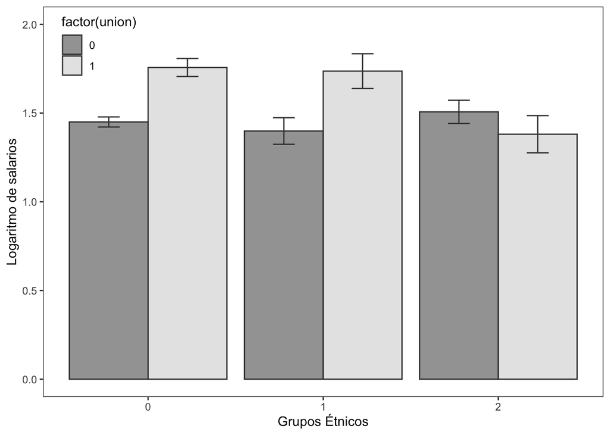

```r
## Gráfico para ayudar la interpretación
library(ggplot2)
datos_salarios %>%
mutate(educ_c = educ - mean_educ) %>%
lm(lwage ~ educ_c + as.factor(ethn) + union  + as.factor(ethn):union, data = .) %>%
emmeans::emmeans(,
    specs = pairwise ~ as.factor(ethn):union,
    type = "response",
    adjust = "bonferroni"
) %>%
purrr::pluck('emmeans') %>%
tibble::as_tibble() %>%
ggplot(., aes(x =  factor(ethn), y = emmean, fill = factor(union))) +
  geom_bar(stat = "identity", position = "dodge", alpha = 0.5, colour = "gray25")  +
  geom_errorbar(aes(ymin=emmean-1.39*SE, ymax=emmean+1.39*SE), position = position_dodge(0.9), width = 0.25,
                show.legend = FALSE, colour = "gray25") +
  labs(x="Grupos Étnicos", y="Logaritmo de salarios") +
  theme_bw() +
  theme(panel.grid.major = element_blank(), panel.grid.minor = element_blank()) +
  ylim(0,2)+
  theme(legend.position = c(0.1, 0.9)) +
  scale_fill_grey()
```

## Respuesta

- Consclusión (Sí/No): No.
- Línea de output interpretada:

`as.factor(ethn)2:union -0.432997 0.098509 -4.396 1.22e-05 ***`

- Descripción de resultados:

Se observa una moderación negativa de la afiliación sindical para los profesores de etnia hispano-latina. Si bien la afiliación sindical es beneficiosa de forma general para todos los profesores, presentando un incremento esperado de 0.30 de logaritmo de salarios entre los profesores (beta = 0.31, SE = 0.04, t(993) = 7.32, p < .001), este incremento esperado se ve anulado por el termino de interación de etnia hipano latina, y afiliación sindical, que corresponde a diferencia de -0.43 sobre el logaritmo de los salarios (beta = -0.43, 95% CI [-0.63, -0.24], t(993) = -4.40, p < .001).

Si comparamos las medias de logaritmo de salarios para todos los grupos generados por los factores de etnia, y afiliación sindical, aplicando ccorrección Bonferroni, podemos resaltar dos comparaciones de interés para el efecto de interación observado. Las medias entre los afiliados al sindicato no presentan diferencias de salarios entre los profesores de la etnia mayoritaria (blancos), con respecto a sus pares afro-americanos afiliados al sindicato. Mientras que sí hay una diferencia a favor de los profesores de la etnia mayoritaria (blancos), y los profesores hispano latinos (delta = 0.38, p < .001).

Si ahora nos fijamos en las comparaciones entre sindicalizados y no sindicalizados por cada grupo etnico, observamos que los profesores hispano-latinos no presentan diferencia de salario (delta = 0.12, t(993) = 1.417, p = 1.00). En contraste, se observan diferencias positivas de salario para los profesores sindicalizados, tanto para los profesores blancos en contraste a sus pares no sindicalizados (delta = 0.31, t(993) = 7.33, p < .0001); como para los profesores afroamericanos sindicalizados (delta = 0.33, t(993) = 3.81, p < .01), en contraste a sus pares no sindicalizados.

# Anexo

Los datos empleados en el taller son ficticios. Los datos siguientes, son los datos empleados en el libro original.

```r
#---------------------------------------------------------
# Datos originales del libro
#---------------------------------------------------------

datos_salarios <- read.csv('salarios8081.csv') %>%
                  mutate(id_i = nr) %>%
                  mutate(ethn = ethnicity) %>%
                  dplyr::filter(year == 1981) %>%
                  dplyr::select(
                  id_i, lwage, ethn, union, educ) %>%
                  dplyr::glimpse()
```

```
## Rows: 545
## Columns: 5
## $ id_i  <int> 13, 17, 18, 45, 110, 120, 126, 150, 162, 166, 189, 193, 209, 212…
## $ lwage <dbl> 1.8530600, 1.5183982, 1.7353791, 1.4711593, 1.9622593, 1.3199717…
## $ ethn  <int> 0, 0, 0, 0, 0, 0, 0, 0, 0, 0, 0, 0, 0, 0, 0, 0, 0, 0, 0, 0, 0, 1…
## $ union <int> 1, 0, 0, 1, 0, 0, 0, 0, 0, 1, 0, 0, 0, 0, 0, 0, 1, 1, 0, 0, 1, 0…
## $ educ  <int> 14, 13, 12, 12, 12, 10, 13, 12, 11, 10, 14, 14, 11, 11, 15, 12, …
```

```r
#---------------------------------------------------------
# Modelo ajustado
#---------------------------------------------------------


mean_educ <- mean(datos_salarios$educ, na.rm = TRUE)

datos_salarios %>%
mutate(educ_c = educ - mean_educ) %>%
lm(lwage ~ educ_c + as.factor(ethn) + union  + as.factor(ethn):union, data = .) %>%
summary()
```

```
##
## Call:
## lm(formula = lwage ~ educ_c + as.factor(ethn) + union + as.factor(ethn):union,
##     data = .)
##
## Residuals:
##      Min       1Q   Median       3Q      Max
## -2.80900 -0.23477  0.05045  0.32210  1.54553
##
## Coefficients:
##                        Estimate Std. Error t value Pr(>|t|)
## (Intercept)             1.44673    0.02920  49.552  < 2e-16 ***
## educ_c                  0.07144    0.01276   5.598 3.45e-08 ***
## as.factor(ethn)1       -0.05624    0.08549  -0.658   0.5109
## as.factor(ethn)2        0.09775    0.07092   1.378   0.1687
## union                   0.28269    0.06005   4.708 3.19e-06 ***
## as.factor(ethn)1:union -0.00791    0.14566  -0.054   0.9567
## as.factor(ethn)2:union -0.34912    0.14315  -2.439   0.0151 *
## ---
## Signif. codes:  0 '***' 0.001 '**' 0.01 '*' 0.05 '.' 0.1 ' ' 1
##
## Residual standard error: 0.5066 on 538 degrees of freedom
## Multiple R-squared:  0.09876,    Adjusted R-squared:  0.08871
## F-statistic: 9.826 on 6 and 538 DF,  p-value: 2.712e-10
```

```r
#---------------------------------------------------------
# Media esperadas (comparaciones multiples)
#---------------------------------------------------------


datos_salarios %>%
mutate(educ_c = educ - mean_educ) %>%
lm(lwage ~ educ_c + as.factor(ethn) + union  + as.factor(ethn):union, data = .) %>%
emmeans::emmeans(,
    specs = pairwise ~ as.factor(ethn):union,
    type = "response",
    adjust = "bonferroni"
    )
```

```
## $emmeans
##  ethn union emmean     SE  df lower.CL upper.CL
##     0     0   1.45 0.0292 538     1.39     1.50
##     1     0   1.39 0.0802 538     1.23     1.55
##     2     0   1.54 0.0641 538     1.42     1.67
##     0     1   1.73 0.0526 538     1.63     1.83
##     1     1   1.67 0.1056 538     1.46     1.87
##     2     1   1.48 0.1133 538     1.26     1.70
##
## Confidence level used: 0.95
##
## $contrasts
##  contrast                    estimate     SE  df t.ratio p.value
##  ethn0 union0 - ethn1 union0   0.0562 0.0855 538   0.658  1.0000
##  ethn0 union0 - ethn2 union0  -0.0977 0.0709 538  -1.378  1.0000
##  ethn0 union0 - ethn0 union1  -0.2827 0.0600 538  -4.708  <.0001
##  ethn0 union0 - ethn1 union1  -0.2185 0.1096 538  -1.994  0.6994
##  ethn0 union0 - ethn2 union1  -0.0313 0.1171 538  -0.267  1.0000
##  ethn1 union0 - ethn2 union0  -0.1540 0.1022 538  -1.507  1.0000
##  ethn1 union0 - ethn0 union1  -0.3389 0.0960 538  -3.532  0.0067
##  ethn1 union0 - ethn1 union1  -0.2748 0.1327 538  -2.071  0.5821
##  ethn1 union0 - ethn2 union1  -0.0876 0.1387 538  -0.631  1.0000
##  ethn2 union0 - ethn0 union1  -0.1849 0.0831 538  -2.224  0.3980
##  ethn2 union0 - ethn1 union1  -0.1208 0.1236 538  -0.977  1.0000
##  ethn2 union0 - ethn2 union1   0.0664 0.1299 538   0.512  1.0000
##  ethn0 union1 - ethn1 union1   0.0642 0.1180 538   0.544  1.0000
##  ethn0 union1 - ethn2 union1   0.2514 0.1250 538   2.011  0.6718
##  ethn1 union1 - ethn2 union1   0.1872 0.1550 538   1.208  1.0000
##
## P value adjustment: bonferroni method for 15 tests
```

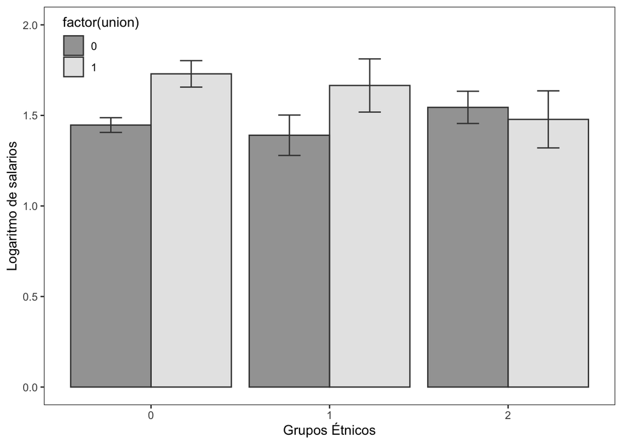

```r
#---------------------------------------------------------
# Grafico de medias con intervalos de confianza a 1.39
#---------------------------------------------------------

library(ggplot2)
datos_salarios %>%
mutate(educ_c = educ - mean_educ) %>%
lm(lwage ~ educ_c + as.factor(ethn) + union  + as.factor(ethn):union, data = .) %>%
emmeans::emmeans(,
    specs = pairwise ~ as.factor(ethn):union,
    type = "response",
    adjust = "bonferroni"
) %>%
purrr::pluck('emmeans') %>%
tibble::as_tibble() %>%
ggplot(., aes(x =  factor(ethn), y = emmean, fill = factor(union))) +
  geom_bar(stat = "identity", position = "dodge", alpha = 0.5, colour = "gray25")  +
  geom_errorbar(aes(ymin=emmean-1.39*SE, ymax=emmean+1.39*SE), position = position_dodge(0.9), width = 0.25,
                show.legend = FALSE, colour = "gray25") +
  labs(x="Grupos Étnicos", y="Logaritmo de salarios") +
  theme_bw() +
  theme(panel.grid.major = element_blank(), panel.grid.minor = element_blank()) +
  ylim(0,2)+
  theme(legend.position = c(0.1, 0.9)) +
  scale_fill_grey()
```

```r
# Nota: se calculan los intervalos de confianza a 1.39; para
#       facilitar las comparaciones multiples, y estas se asemejen
#       a la prueba estadistica empleada, comparaciones de medias multiples,
#       con corrección bonferroni (ver Goldstein & Healy, 1995).
```

# Referencias

Goldstein, H., & Healy, M. J. R. (1995). The Graphical Presentation of a Collection of Means. Journal of Chemical Information and Modeling, 158(1), 175–177. https://doi.org/10.1017/CBO9781107415324.004